# Facebook comments / Data science project

Judit Szlameniczky

March 19, 2017

## **1. Introduction**

The leading treads towards social networking services, such as Facebook and Twitter had drawn massive public attention in the last decade. The amount of data that is uploaded to these social networking services is increasing day by day. So, there is an increasing need to study the highly dynamic behavior of users towards these services. This project work to model user patterns of Facebook. I used the dataset to predict if a post is expected to receive comments in the next H hrs. I used Ranom Forest, GBM and Neural Networks for modelling. I evaluated them based on Area Under Curve, F1 score and classification error metrics and I concluded that Random Forest model performs the best.

## **2. Data cleaning and exploration**

### **Data used for the project**

Access to the dataset: [Dataset](http://archive.ics.uci.edu/ml/datasets/Facebook%20Comment%20Volume%20Dataset#)  
The dataset has been reduced due to computer capacity. The version used contains 20295 observations and 29 variables.

### **Predictors and the predicted variable:**

Below is the description of the variables used for prediction:  
(Note: They were named as per their descriptions, also some of the original variables have been removed before the analysis due to lack of information about their purpose):

**Page Popularity/likes:** Defines the popularity or support for the source of the document  
**Page Checkins:** Describes how many individuals so far visited this place. This feature is only associated with the places eg:some institution, place, theater etc.  
**Page talking about:** Defines the daily interest of individuals towards source of the document/ Post. The people who actually come back to the page, after liking the page. This include activities such as comments, likes to a post, shares, etc by visitors to the page.  
**Page Category:** Defines the category of the source of the document eg: place, institution, brand etc.  
**CC1:** The total number of comments before selected base date/time.  
**CC2:** The number of comments in last 24 hours, relative to base date/time.  
**CC3:** The number of comments in last 48 to last 24 hours relative to base date/time.  
**CC4:** The number of comments in the first 24 hours after the publication of post but before base date/time.  
**CC5:** The difference between CC2 and CC3.  
**Base time:** Selected time in order to simulate the scenario.  
**Post length:** Character count in the post.  
**Post Share Count:** This features counts the no of shares of the post, that how many peoples had shared this post on to their timeline.  
**Post Promotion Status:** To reach more people with posts in News Feed, individual promote their post and this features tells that whether the post is promoted(1) or not(0).  
**H Local:** This describes the H hrs, for which we have the target variable/ comments received.  
**PostSun - PostSat:** This represents the day(Sunday…Saturday) on which the post was published.  
**BaseSun-BaseSat:** This represents the day(Sunday…Saturday) on selected base Date/Time.  
**Target Variable:** The no of comments in next H hrs(H is given in Feature no 39).

### **Set up and loading libraries, loading data**

```r
# install.packages("randomForest")
# install.packages("DMwR")
# install.packages("PRROC")
# install.packages("ROCR")
# install.packages("nnet")
# install.packages("caret")
library(DMwR)
library(ROCR)
library(ggplot2)
library(randomForest)
library(nnet)
library(caret)
library(PRROC)
library(readr)
library(dplyr)
library(reshape2)
library(ggplot2)
library(knitr)

getwd()
```

```
## [1] "F:/CEU/Data Science/Dataset"
```

```r
setwd("F:\\CEU\\Data Science\\Dataset\\Dataset\\Training")
data <- read.csv("Features_Variant_7.csv")


#Exploratory data analysis

#Quick look and cleaning
head(data)
```

```
##   Page.Popularity.likes Page.Checkins Page.talking.about Page.Category CC1
## 1                634995             0                463             1   0
## 2                634995             0                463             1   0
## 3                634995             0                463             1   0
## 4                634995             0                463             1   7
## 5                634995             0                463             1   1
## 6                634995             0                463             1   0
##   CC2 CC3 CC4 CC5 Base.time Post.length Post.Share.Count
## 1   0   0   0   0        25         166                2
## 2   0   0   0   0        70         132                1
## 3   0   0   0   0        26         133                2
## 4   0   0   7   0        67         131                1
## 5   0   0   1   0        65         142                5
## 6   0   0   0   0        22         166                1
##   Post.Promotion.Status H.Local PostSun PostMon PostTue PostWed PostThu
```

[output cut: 20 more lines]

```r
dim(data)
```

```
## [1] 20295    29
```

```r
str(data)
```

```
## 'data.frame':    20295 obs. of  29 variables:
##  $ Page.Popularity.likes: int  634995 634995 634995 634995 634995 634995 634995 634995 634995 634995 ...
##  $ Page.Checkins        : int  0 0 0 0 0 0 0 0 0 0 ...
##  $ Page.talking.about   : int  463 463 463 463 463 463 463 463 463 463 ...
##  $ Page.Category        : int  1 1 1 1 1 1 1 1 1 1 ...
##  $ CC1                  : int  0 0 0 7 1 0 0 0 0 0 ...
##  $ CC2                  : int  0 0 0 0 0 0 0 0 0 0 ...
##  $ CC3                  : int  0 0 0 0 0 0 0 0 0 0 ...
##  $ CC4                  : int  0 0 0 7 1 0 0 0 0 0 ...
##  $ CC5                  : int  0 0 0 0 0 0 0 0 0 0 ...
##  $ Base.time            : int  25 70 26 67 65 22 5 2 38 15 ...
##  $ Post.length          : int  166 132 133 131 142 166 145 157 177 126 ...
##  $ Post.Share.Count     : int  2 1 2 1 5 1 2 2 5 1 ...
##  $ Post.Promotion.Status: int  0 0 0 0 0 0 0 0 0 0 ...
##  $ H.Local              : int  24 24 24 24 24 24 24 24 24 24 ...
##  $ PostSun              : int  0 0 0 0 0 0 0 0 0 0 ...
##  $ PostMon              : int  0 0 0 0 1 0 0 0 0 0 ...
##  $ PostTue              : int  0 0 0 0 0 1 0 0 0 0 ...
##  $ PostWed              : int  1 0 0 0 0 0 1 0 0 0 ...
##  $ PostThu              : int  0 1 0 0 0 0 0 1 0 0 ...
##  $ PostFri              : int  0 0 1 1 0 0 0 0 1 1 ...
##  $ PostSat              : int  0 0 0 0 0 0 0 0 0 0 ...
##  $ BaseSun              : int  0 1 0 0 0 0 0 0 0 0 ...
##  $ BaseMon              : int  0 0 0 1 0 0 0 0 0 0 ...
##  $ BaseTue              : int  0 0 0 0 0 0 0 0 0 0 ...
##  $ BaseWed              : int  0 0 0 0 0 1 1 0 0 0 ...
##  $ BasedThu             : int  1 0 0 0 1 0 0 1 0 0 ...
##  $ BaseFri              : int  0 0 0 0 0 0 0 0 0 0 ...
##  $ BaseSat              : int  0 0 1 0 0 0 0 0 1 1 ...
##  $ Target.Variable      : int  0 0 0 0 0 0 0 1 0 0 ...
```

```r
colnames(data)
```

```
##  [1] "Page.Popularity.likes" "Page.Checkins"
##  [3] "Page.talking.about"    "Page.Category"
##  [5] "CC1"                   "CC2"
##  [7] "CC3"                   "CC4"
##  [9] "CC5"                   "Base.time"
## [11] "Post.length"           "Post.Share.Count"
## [13] "Post.Promotion.Status" "H.Local"
## [15] "PostSun"               "PostMon"
## [17] "PostTue"               "PostWed"
## [19] "PostThu"               "PostFri"
## [21] "PostSat"               "BaseSun"
## [23] "BaseMon"               "BaseTue"
## [25] "BaseWed"               "BasedThu"
## [27] "BaseFri"               "BaseSat"
## [29] "Target.Variable"
```

```r
summary(data)
```

```
##  Page.Popularity.likes Page.Checkins    Page.talking.about Page.Category
##  Min.   :      530     Min.   :     0   Min.   :      0    Min.   : 1.00
##  1st Qu.:   188849     1st Qu.:     0   1st Qu.:    745    1st Qu.: 9.00
##  Median :   579587     Median :     0   Median :  20529    Median :18.00
##  Mean   :  2072142     Mean   :  9695   Mean   :  57258    Mean   :17.24
##  3rd Qu.:  2516731     3rd Qu.:    39   3rd Qu.:  74450    3rd Qu.:24.00
##  Max.   :162624443     Max.   :122388   Max.   :1242488    Max.   :39.00
##       CC1               CC2               CC3               CC4
##  Min.   :   0.00   Min.   :   0.00   Min.   :   0.00   Min.   :   0.00
##  1st Qu.:   3.00   1st Qu.:   0.00   1st Qu.:   0.00   1st Qu.:   3.00
##  Median :  19.00   Median :   3.00   Median :   1.00   Median :  18.00
##  Mean   :  80.56   Mean   :  31.08   Mean   :  29.06   Mean   :  75.67
##  3rd Qu.:  71.00   3rd Qu.:  19.00   3rd Qu.:  15.00   3rd Qu.:  67.00
##  Max.   :2495.00   Max.   :1879.00   Max.   :1963.00   Max.   :2106.00
##       CC5              Base.time     Post.length      Post.Share.Count
##  Min.   :-1559.000   Min.   : 0.0   Min.   :    0.0   Min.   :    1
##  1st Qu.:  -10.000   1st Qu.:17.0   1st Qu.:   48.0   1st Qu.:    3
##  Median :    0.000   Median :35.0   Median :  101.0   Median :   27
##  Mean   :    2.024   Mean   :35.3   Mean   :  177.3   Mean   :  144
##  3rd Qu.:    5.000   3rd Qu.:53.0   3rd Qu.:  177.0   3rd Qu.:  105
##  Max.   : 1879.000   Max.   :72.0   Max.   :21480.0   Max.   :11710
##  Post.Promotion.Status    H.Local         PostSun          PostMon
##  Min.   :0             Min.   : 1.00   Min.   :0.0000   Min.   :0.0000
##  1st Qu.:0             1st Qu.:24.00   1st Qu.:0.0000   1st Qu.:0.0000
##  Median :0             Median :24.00   Median :0.0000   Median :0.0000
##  Mean   :0             Mean   :23.77   Mean   :0.1186   Mean   :0.1589
##  3rd Qu.:0             3rd Qu.:24.00   3rd Qu.:0.0000   3rd Qu.:0.0000
##  Max.   :0             Max.   :24.00   Max.   :1.0000   Max.   :1.0000
##     PostTue          PostWed          PostThu          PostFri
##  Min.   :0.0000   Min.   :0.0000   Min.   :0.0000   Min.   :0.0000
##  1st Qu.:0.0000   1st Qu.:0.0000   1st Qu.:0.0000   1st Qu.:0.0000
##  Median :0.0000   Median :0.0000   Median :0.0000   Median :0.0000
##  Mean   :0.1574   Mean   :0.1474   Mean   :0.1477   Mean   :0.1495
##  3rd Qu.:0.0000   3rd Qu.:0.0000   3rd Qu.:0.0000   3rd Qu.:0.0000
##  Max.   :1.0000   Max.   :1.0000   Max.   :1.0000   Max.   :1.0000
##     PostSat          BaseSun          BaseMon          BaseTue
##  Min.   :0.0000   Min.   :0.0000   Min.   :0.0000   Min.   :0.0000
##  1st Qu.:0.0000   1st Qu.:0.0000   1st Qu.:0.0000   1st Qu.:0.0000
##  Median :0.0000   Median :0.0000   Median :0.0000   Median :0.0000
##  Mean   :0.1205   Mean   :0.1409   Mean   :0.1321   Mean   :0.1366
##  3rd Qu.:0.0000   3rd Qu.:0.0000   3rd Qu.:0.0000   3rd Qu.:0.0000
##  Max.   :1.0000   Max.   :1.0000   Max.   :1.0000   Max.   :1.0000
##     BaseWed          BasedThu         BaseFri          BaseSat
##  Min.   :0.0000   Min.   :0.0000   Min.   :0.0000   Min.   :0.0000
##  1st Qu.:0.0000   1st Qu.:0.0000   1st Qu.:0.0000   1st Qu.:0.0000
##  Median :0.0000   Median :0.0000   Median :0.0000   Median :0.0000
##  Mean   :0.1535   Mean   :0.1557   Mean   :0.1446   Mean   :0.1366
##  3rd Qu.:0.0000   3rd Qu.:0.0000   3rd Qu.:0.0000   3rd Qu.:0.0000
##  Max.   :1.0000   Max.   :1.0000   Max.   :1.0000   Max.   :1.0000
##  Target.Variable
##  Min.   :   0.00
##  1st Qu.:   0.00
##  Median :   1.00
##  Mean   :  10.36
##  3rd Qu.:   5.00
##  Max.   :1235.00
```

```r
sapply(data, function(x) sum(is.na(x)))
```

```
## Page.Popularity.likes         Page.Checkins    Page.talking.about
##                     0                     0                     0
##         Page.Category                   CC1                   CC2
##                     0                     0                     0
##                   CC3                   CC4                   CC5
##                     0                     0                     0
##             Base.time           Post.length      Post.Share.Count
##                     0                     0                     0
## Post.Promotion.Status               H.Local               PostSun
##                     0                     0                     0
##               PostMon               PostTue               PostWed
##                     0                     0                     0
##               PostThu               PostFri               PostSat
##                     0                     0                     0
##               BaseSun               BaseMon               BaseTue
##                     0                     0                     0
##               BaseWed              BasedThu               BaseFri
##                     0                     0                     0
##               BaseSat       Target.Variable
##                     0                     0
```

### **Descriptive statistics**

**Page Popularity/likes**

The distribution of Page Popularity/likes shows a skewed distribution with a long right tail. The values largly vary between 530 and 162600000 with outliers at the higher end.

```r
##Page.Popularity.likes
summary(data$Page.Popularity.likes)
```

```
##      Min.   1st Qu.    Median      Mean   3rd Qu.      Max.
##       530    188800    579600   2072000   2517000 162600000
```

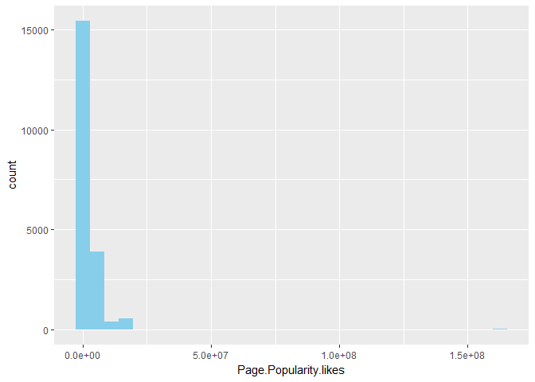

```r
ggplot(data) + geom_histogram(aes(x = Page.Popularity.likes), fill = 'skyblue')
```

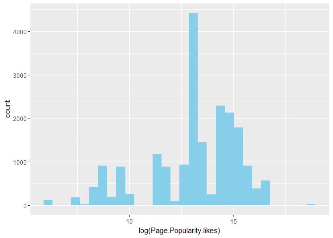

```r
ggplot(data) + geom_histogram(aes(x = log(Page.Popularity.likes)), fill = 'skyblue')
```

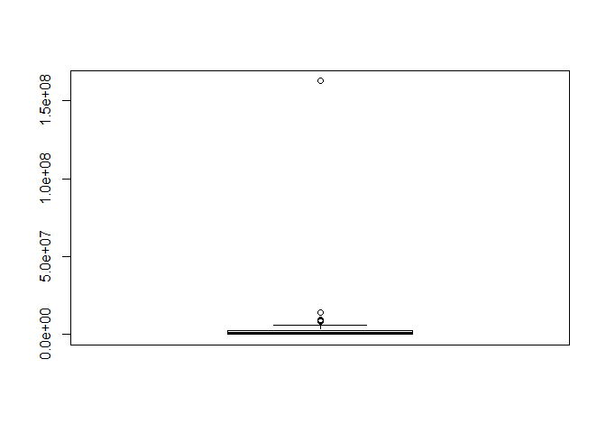

```r
boxplot(data$Page.Popularity.likes)
```

Drop outliers above 10,000,000:

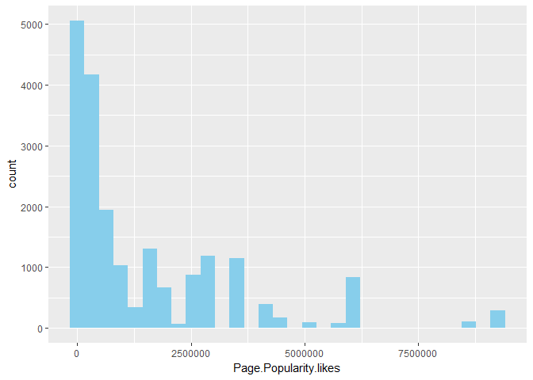

```r
##Drop outliers
data <- subset(data,Page.Popularity.likes < 10000000)
ggplot(data) + geom_histogram(aes(x = Page.Popularity.likes), fill = 'skyblue')
```

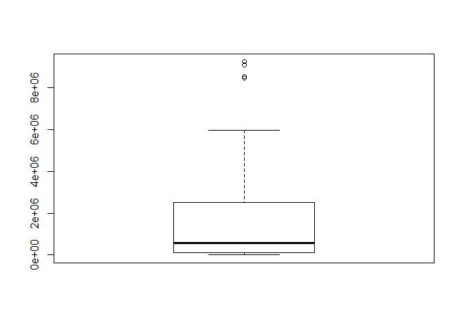

```r
boxplot(data$Page.Popularity.likes)
```

**Page Checkins**

Page Checkins also show a skewed distribution with a long right tail with some outliers.

```r
##Page.Checkins
summary(data$Page.Checkins)
```

```
##    Min. 1st Qu.  Median    Mean 3rd Qu.    Max.
##       0       0       0    9990      83  122400
```

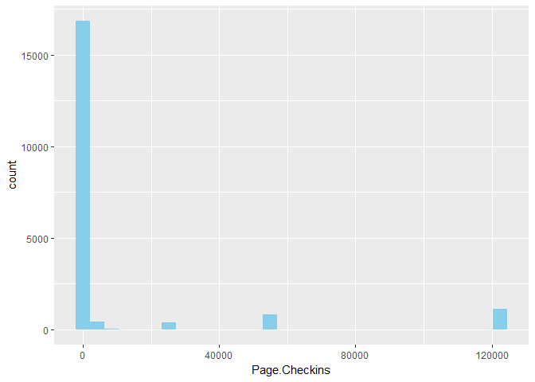

```r
ggplot(data) + geom_histogram(aes(x = Page.Checkins), fill = 'skyblue')
```

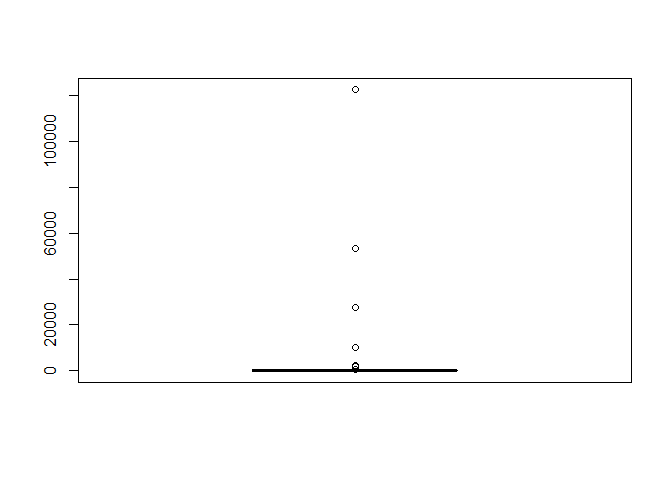

```r
boxplot(data$Page.Checkins)
```

**Page talking about**

Page talking about variable does not show any specific pattern. It is rather skewed with a left tail.

```r
##Page.talking.about
summary(data$Page.talking.about)
```

```
##    Min. 1st Qu.  Median    Mean 3rd Qu.    Max.
##       0     745   19300   56150   77240  297500
```

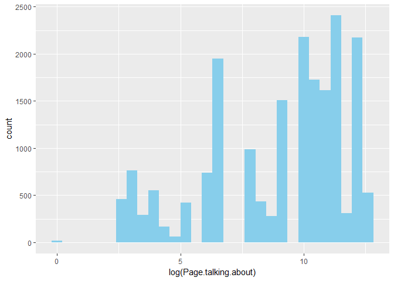

```r
ggplot(data) + geom_histogram(aes(x = log(Page.talking.about)), fill = 'skyblue')
```

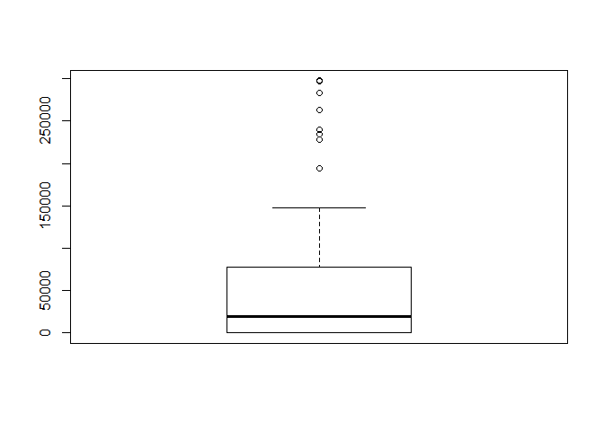

```r
boxplot(data$Page.talking.about)
```

**Page category**

Page category is quite scattered, 9 being the most frequent one.

```r
##Page.category
summary(data$Page.Category)
```

```
##    Min. 1st Qu.  Median    Mean 3rd Qu.    Max.
##    1.00    9.00   17.00   17.19   24.00   39.00
```

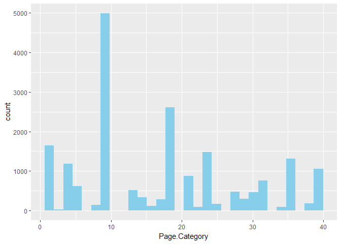

```r
ggplot(data) + geom_histogram(aes(x = Page.Category), fill = 'skyblue')
```

**Page length**

Page length has a skewed distribution with a long right tail.

```r
summary(data$Post.length)
```

```
##    Min. 1st Qu.  Median    Mean 3rd Qu.    Max.
##     0.0    45.0    99.0   177.8   176.0 21480.0
```

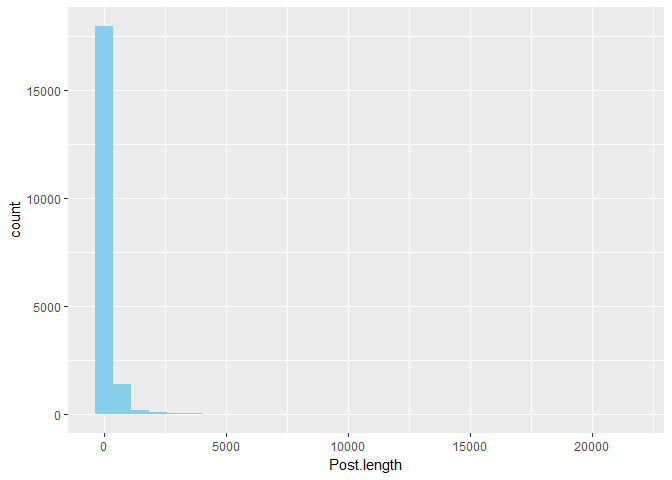

```r
ggplot(data) + geom_histogram(aes(x = Post.length), fill = 'skyblue')
```

**Page share count**

Page share count has a skewed distribution with a long right tail.

```r
##Post.Share.Count
summary(data$Post.Share.Count)
```

```
##    Min. 1st Qu.  Median    Mean 3rd Qu.    Max.
##     1.0     3.0    25.0   145.2   105.0 11710.0
```

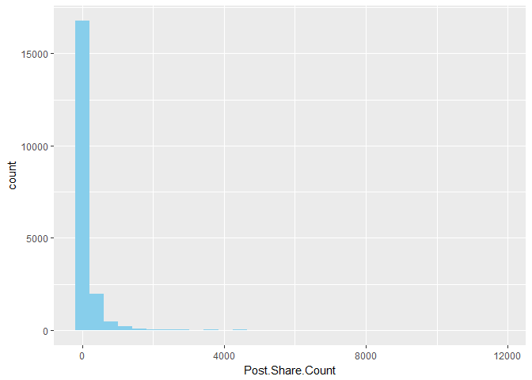

```r
ggplot(data) + geom_histogram(aes(x = Post.Share.Count), fill = 'skyblue')
```

**Post day of the week**

The number of comments show a very similar distribution for each day of the week with minor differences, such as lower numbers over the weekends.

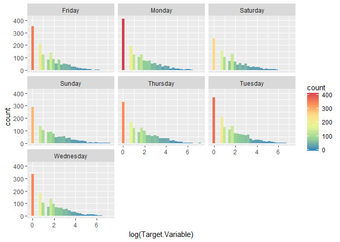

```r
#Post day of week
data$day[data$PostMon == 1] <- "Monday"
data$day[data$PostTue == 1] <- "Tuesday"
data$day[data$PostWed == 1] <- "Wednesday"
data$day[data$PostThu == 1] <- "Thursday"
data$day[data$PostFri == 1] <- "Friday"
data$day[data$PostSat == 1] <- "Saturday"
data$day[data$PostSun == 1] <- "Sunday"

ggplot(data, aes(x = log(Target.Variable))) +
  geom_histogram(aes(fill=..count..))+facet_wrap(~day)+scale_fill_distiller(palette="Spectral")
```

**Basetime day of week**

Like the day of the post, basetime day distribution pattern is very similar for each day of the week. In this case weekends does not show a difference either.

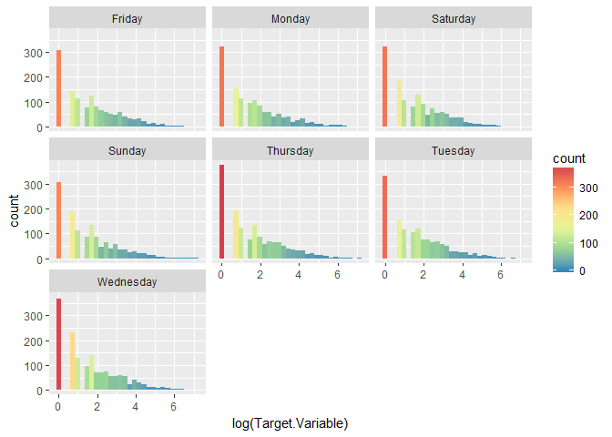

```r
#Basetime day of week
data$baseday[data$BaseMon == 1] <- "Monday"
data$baseday[data$BaseTue == 1] <- "Tuesday"
data$baseday[data$BaseWed == 1] <- "Wednesday"
data$baseday[data$BasedThu == 1] <- "Thursday"
data$baseday[data$BaseFri == 1] <- "Friday"
data$baseday[data$BaseSat == 1] <- "Saturday"
data$baseday[data$BaseSun == 1] <- "Sunday"

ggplot(data, aes(x = log(Target.Variable))) +
  geom_histogram(aes(fill=..count..))+facet_wrap(~baseday)+scale_fill_distiller(palette="Spectral")
```

#### Target variable

**Original Target variable**

The original target variable shows the number of comments the post received within H hours after the basetime. Its distribution is skewed with a long right tail.

```r
#Target Variable

summary(data$New.Target.Variable)
```

```
## Length  Class   Mode
##      0   NULL   NULL
```

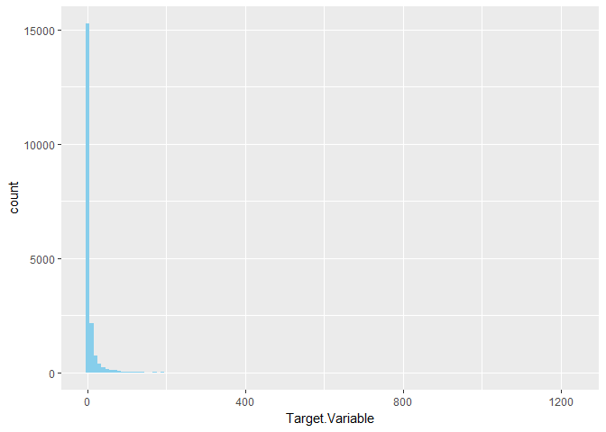

```r
ggplot(data) + geom_histogram(aes(x =Target.Variable), fill = 'skyblue', binwidth = 10)
```

**Create new target variable**

In order to turn this exercise into a classification, I introduced a new target variable that indicates whether a post received comments or not. The number of observations in each category is quite balanced as it can be concluded from the histogram as well.

```r
#creating new target variable to show if post got comments
data$New.Target.Variable[data$Target.Variable == 0] <- "no comments"
data$New.Target.Variable[data$Target.Variable > 0] <- "comments"

summary(data$New.Target.Variable)
```

```
##    Length     Class      Mode
##     19694 character character
```

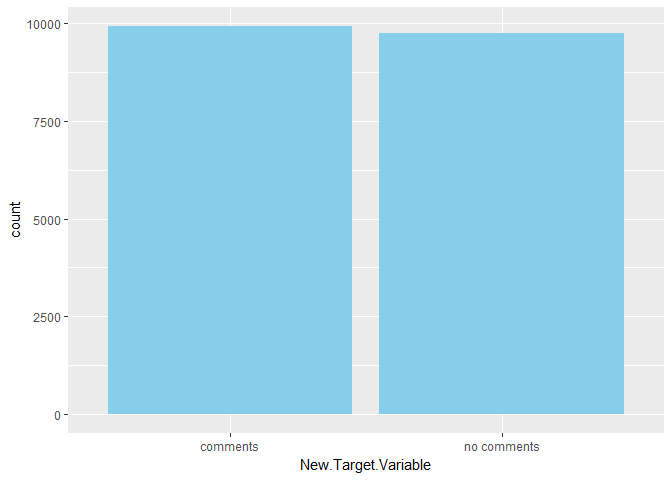

```r
ggplot(data) + geom_bar(aes(x = New.Target.Variable), fill = 'skyblue')
```

## **3. Machine learning**

### **Split data set**

As a start, I splitted the dataset into training, test and validation data. I ended up with 9847 observations in the trainig set, 4923 in the validation set and 4924 in the test set.

```r
#Split train/test
set.seed(123)
N <- nrow(data)
idx_train <- sample(1:N,N/2)
idx_valid <- sample(base::setdiff(1:N, idx_train), N/4)
idx_test <- base::setdiff(base::setdiff(1:N, idx_train),idx_valid)
data$day<-as.factor(data$day)
data$baseday<-as.factor(data$baseday)
data$New.Target.Variable<-as.factor(data$New.Target.Variable)
data$Target.Variable<-NULL
d_train <- data[idx_train,]
d_valid <- data[idx_valid,]
d_test  <- data[idx_test,]

library(h2o)

h2o.init()
```

[output not shown]

```r
h2o.removeAll()
```

```
## [1] 0
```

```r
dx_train <- as.h2o(d_train)
dx_train$New.Target.Variable <- as.factor(dx_train$New.Target.Variable)
dx_valid <- as.h2o(d_valid)
dx_valid$New.Target.Variable <- as.factor(dx_valid$New.Target.Variable)
dx_test <- as.h2o(d_test)
dx_test$New.Target.Variable <- as.factor(dx_test$New.Target.Variable)
```

### **Modelling**

I used three methods - Random Forest, GBM and Neural Network- which I then compared to each other to be able to choose the best model.  
I extracted and visualized the performance metrics F1 and ROC curve for both the validation and the test set for each model and the confusion matrix (see below). I also included the most important predictors.

#### **Random Forest**

```r
h2o.rm("RF")

RF <- h2o.randomForest(
  training_frame = dx_train,
  validation_frame = dx_valid,
  x=colnames(dx_train)[-5][-5][-5][-5][-5][-25],
  y="New.Target.Variable",
  seed=1234,
  ntrees=100
)
```

##### *AUC*

```r
RFp<-h2o.performance(RF,valid=T)
h2o.auc(RFp)
```

```
## [1] 0.9271865
```

```r
RFrp<-cbind(h2o.fpr(RFp),h2o.tpr(RFp)$tpr)
colnames(RFrp)[3]<-"tpr"
RFt<-h2o.performance(RF,newdata = dx_test)
RFrt<-cbind(h2o.fpr(RFt),h2o.tpr(RFt)$tpr)
h2o.auc(RFt)
```

```
## [1] 0.922385
```

##### *Performance metrics*

The following two graphs show the F1 metrics and ROC curve with different threshold for validation set and test set (in this order), both figures use a warmer color for lower threshold.

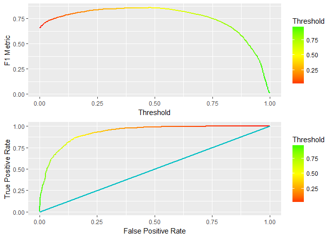

```r
colnames(RFrt)[3]<-"tpr"
RFev<-ggplot(h2o.F1(RFp))+geom_line(aes(x=threshold,y=f1,color=threshold),size=1)+
  scale_color_gradient2("Threshold",low="red",high="green",mid="yellow",midpoint = 0.5)+
  xlab("Threshold")+ylab("F1 Metric")
RFet<-ggplot(h2o.F1(RFt))+geom_line(aes(x=threshold,y=f1,color=threshold),size=1)+
  scale_color_gradient2("Threshold",low="red",high="green",mid="yellow",midpoint = 0.5)+
  xlab("Threshold")+ylab("F1 Metric")
RFav<-ggplot(RFrp,aes(x=fpr,y=tpr))+geom_line(aes(col=threshold),size=1)+xlab("False Positive Rate")+ylab("True Positive Rate")+
  scale_color_gradient2("Threshold",low="red",high="green",mid="yellow",midpoint = 0.5)+
  geom_segment(x=0,y=0,xend=1,yend=1,size=1,col="#00BFC4")
RFat<-ggplot(RFrt,aes(x=fpr,y=tpr))+geom_line(aes(col=threshold),size=1)+xlab("False Positive Rate")+ylab("True Positive Rate")+
  scale_color_gradient2("Threshold",low="red",high="green",mid="yellow",midpoint = 0.5)+
  geom_segment(x=0,y=0,xend=1,yend=1,size=1,col="#00BFC4")
#install.packages("gridExtra")
library(gridExtra)
grid.arrange(RFev,RFav,ncol=1)
```

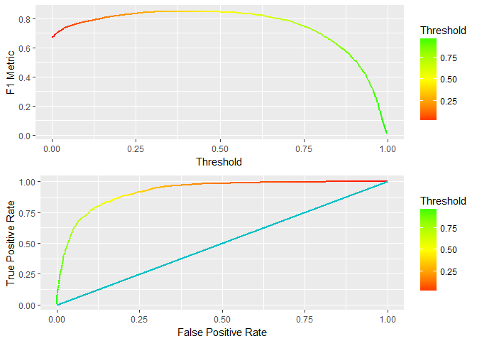

```r
grid.arrange(RFet,RFat,ncol=1)
```

```r
library(data.table)
```

##### *Important predictors*

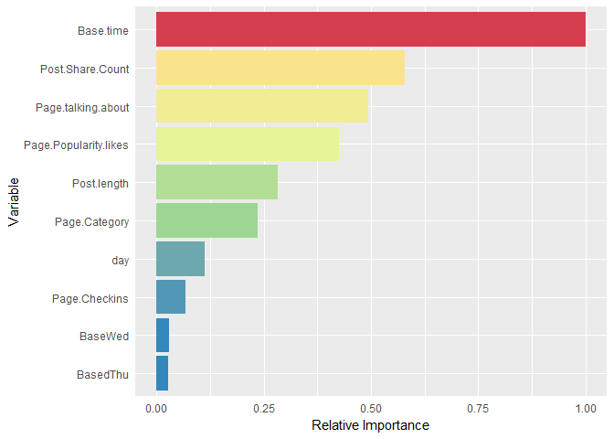

```r
ggplot(data.table(cbind(h2o.varimp(RF)$variable[1:10],h2o.varimp(RF)$scaled_importance[1:10],h2o.varimp(RF)$relative_importance[1:10])))+
  geom_col(aes(x=V1,y=as.numeric(V2),fill=as.numeric(V3)))+coord_flip()+scale_x_discrete(limits=rev(h2o.varimp(RF)$variable[1:10]))+
  scale_y_continuous(breaks=seq(0,1,0.25))+
  theme(axis.ticks=element_blank())+ylab("Relative Importance")+xlab("Variable")+
  scale_fill_distiller(palette="Spectral",guide=F)
```

##### *Confusion matrix*

```r
h2o.confusionMatrix(RFp,metrics="f1")[,1:3]
```

```
##             comments no comments     Error
## comments        2091         411 0.1642686
## no comments      302        2119 0.1247418
## Totals          2393        2530 0.1448304
```

```r
h2o.confusionMatrix(RFt,metrics="f1")[,1:3]
```

```
##             comments no comments     Error
## comments        1947         490 0.2010669
## no comments      285        2202 0.1145959
## Totals          2232        2692 0.1573924
```

#### **GBM**

```r
##GBM
GBM <- h2o.gbm(
  training_frame = dx_train,
  validation_frame = dx_valid,
  x=colnames(dx_train)[-5][-5][-5][-5][-5][-25],
  y="New.Target.Variable",
  seed=1234,
  ntrees=100
)
```

##### *AUC*

```r
GBMp<-h2o.performance(GBM,valid=T)
h2o.auc(GBMp)
```

```
## [1] 0.9179386
```

```r
GBMrp<-cbind(h2o.fpr(GBMp),h2o.tpr(GBMp)$tpr)
colnames(GBMrp)[3]<-"tpr"
GBMt<-h2o.performance(GBM,newdata = dx_test)
GBMrt<-cbind(h2o.fpr(GBMt),h2o.tpr(GBMt)$tpr)
h2o.auc(GBMt)
```

```
## [1] 0.9121382
```

```r
colnames(GBMrt)[3]<-"tpr"
```

##### *Performance metrics*

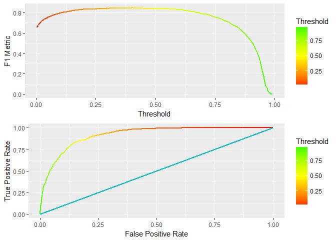

```r
GBMev<-ggplot(h2o.F1(GBMp))+geom_line(aes(x=threshold,y=f1,color=threshold),size=1)+
  scale_color_gradient2("Threshold",low="red",high="green",mid="yellow",midpoint = 0.5)+
  xlab("Threshold")+ylab("F1 Metric")
GBMet<-ggplot(h2o.F1(GBMt))+geom_line(aes(x=threshold,y=f1,color=threshold),size=1)+
  scale_color_gradient2("Threshold",low="red",high="green",mid="yellow",midpoint = 0.5)+
  xlab("Threshold")+ylab("F1 Metric")
GBMav<-ggplot(GBMrp,aes(x=fpr,y=tpr))+geom_line(aes(col=threshold),size=1)+xlab("False Positive Rate")+ylab("True Positive Rate")+
  scale_color_gradient2("Threshold",low="red",high="green",mid="yellow",midpoint = 0.5)+
  geom_segment(x=0,y=0,xend=1,yend=1,size=1,col="#00BFC4")
GBMat<-ggplot(GBMrt,aes(x=fpr,y=tpr))+geom_line(aes(col=threshold),size=1)+xlab("False Positive Rate")+ylab("True Positive Rate")+
  scale_color_gradient2("Threshold",low="red",high="green",mid="yellow",midpoint = 0.5)+
  geom_segment(x=0,y=0,xend=1,yend=1,size=1,col="#00BFC4")
#install.packages("gridExtra")
library(gridExtra)
grid.arrange(GBMev,GBMav,ncol=1)
```

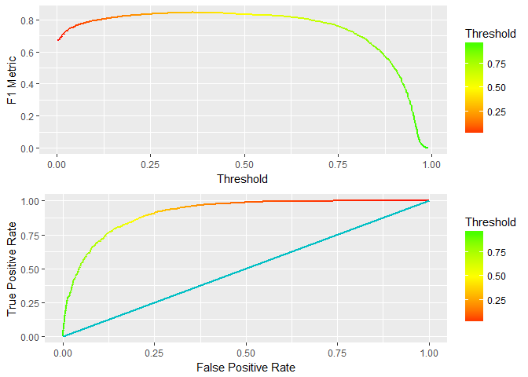

```r
grid.arrange(GBMet,GBMat,ncol=1)
```

```r
library(data.table)
```

##### *Important predictors*

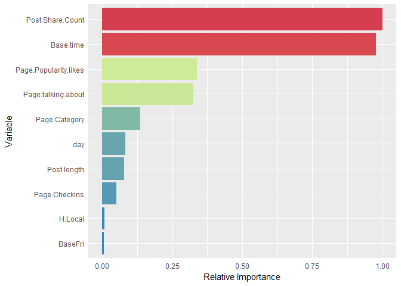

```r
ggplot(data.table(cbind(h2o.varimp(GBM)$variable[1:10],h2o.varimp(GBM)$scaled_importance[1:10],h2o.varimp(GBM)$relative_importance[1:10])))+
  geom_col(aes(x=V1,y=as.numeric(V2),fill=as.numeric(V3)))+coord_flip()+scale_x_discrete(limits=rev(h2o.varimp(GBM)$variable[1:10]))+
  scale_y_continuous(breaks=seq(0,1,0.25))+
  theme(axis.ticks=element_blank())+ylab("Relative Importance")+xlab("Variable")+
  scale_fill_distiller(palette="Spectral",guide=F)
```

##### *Confusion matrix*

```r
h2o.confusionMatrix(GBMp,metrics="f1")[,1:3]
```

```
##             comments no comments      Error
## comments        1948         554 0.22142286
## no comments      240        2181 0.09913259
## Totals          2188        2735 0.16128377
```

```r
h2o.confusionMatrix(GBMt,metrics="f1")[,1:3]
```

```
##             comments no comments      Error
## comments        1818         619 0.25400082
## no comments      205        2282 0.08242863
## Totals          2023        2901 0.16734362
```

#### **Neural Network**

```r
##NN
NN <- h2o.deeplearning(
  training_frame = dx_train,
  validation_frame = dx_valid,
  x=colnames(dx_train)[-5][-5][-5][-5][-5][-25],
  y="New.Target.Variable",
  seed=1234
)
```

##### *AUC*

```r
NNp<-h2o.performance(NN,valid=T)
h2o.auc(NNp)
```

```
## [1] 0.8962538
```

```r
NNrp<-cbind(h2o.fpr(NNp),h2o.tpr(NNp)$tpr)
colnames(NNrp)[3]<-"tpr"
NNt<-h2o.performance(NN,newdata = dx_test)
NNrt<-cbind(h2o.fpr(NNt),h2o.tpr(NNt)$tpr)
h2o.auc(NNt)
```

```
## [1] 0.8883851
```

```r
colnames(NNrt)[3]<-"tpr"
```

##### *Performance metrics*

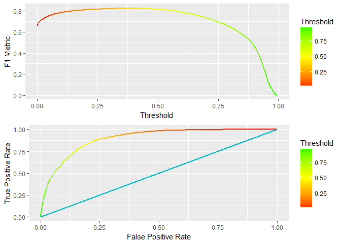

```r
NNev<-ggplot(h2o.F1(NNp))+geom_line(aes(x=threshold,y=f1,color=threshold),size=1)+
  scale_color_gradient2("Threshold",low="red",high="green",mid="yellow",midpoint = 0.5)+
  xlab("Threshold")+ylab("F1 Metric")
NNet<-ggplot(h2o.F1(NNt))+geom_line(aes(x=threshold,y=f1,color=threshold),size=1)+
  scale_color_gradient2("Threshold",low="red",high="green",mid="yellow",midpoint = 0.5)+
  xlab("Threshold")+ylab("F1 Metric")
NNav<-ggplot(NNrp,aes(x=fpr,y=tpr))+geom_line(aes(col=threshold),size=1)+xlab("False Positive Rate")+ylab("True Positive Rate")+
  scale_color_gradient2("Threshold",low="red",high="green",mid="yellow",midpoint = 0.5)+
  geom_segment(x=0,y=0,xend=1,yend=1,size=1,col="#00BFC4")
NNat<-ggplot(NNrt,aes(x=fpr,y=tpr))+geom_line(aes(col=threshold),size=1)+xlab("False Positive Rate")+ylab("True Positive Rate")+
  scale_color_gradient2("Threshold",low="red",high="green",mid="yellow",midpoint = 0.5)+
  geom_segment(x=0,y=0,xend=1,yend=1,size=1,col="#00BFC4")
#install.packages("gridExtra")
library(gridExtra)
grid.arrange(NNev,NNav,ncol=1)
```

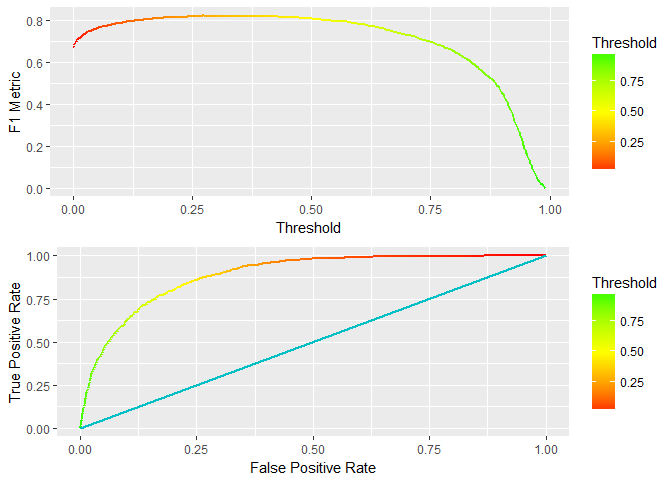

```r
grid.arrange(NNet,NNat,ncol=1)
```

```r
library(data.table)
```

##### *Confusion matrix*

```r
h2o.confusionMatrix(NNp,metrics="f1")[,1:3]
```

```
##             comments no comments     Error
## comments        1902         600 0.2398082
## no comments      282        2139 0.1164808
## Totals          2184        2739 0.1791590
```

```r
h2o.confusionMatrix(NNt,metrics="f1")[,1:3]
```

```
##             comments no comments      Error
## comments        1591         846 0.34714813
## no comments      159        2328 0.06393245
## Totals          1750        3174 0.20410236
```

## **4. Summary**

Below table summarizes the AUC, F1 score and Classification error of the test set for each model:

| Metrics | RF | GBM | NN |
| --- | --- | --- | --- |
| AUC | 0.9224 | 0.9121 | 0.8884 |
| F1 | 0.8504 | 0.8471 | 0.8225 |
| Error (FN/P) | 0.1146 | 0.0824 | 0.0639 |
| Error (FP/N) | 0.2011 | 0.254 | 0.3471 |